# Влияние кризиса 2008 года на различные страны и/или регионы

В рамках тестового задания было поручено исследование того, как на различных странах и/или регионах отразился кризис 2008 года.

**Цель:** создать 3-4 наглядных отчета влияния кризиса 2008 года на различных странах и/или регионах (на наш выбор), найти и представить интересные закономерности.

В качестве **входных данных** мы получили файл в формате `.xlsx`, содержащий различные вкладки со статистическими даннными по странам и справочником регионов.

К тестовому заданию шли следующие комментарии.

**КОММЕНТАРИИ**

1. Необходимые для отчетов данные, возможно, нужно будет привести «в порядок» - исправить форматы числовых данных, проанализировать корректность значений
2. Все отчеты желательно сопровождать выводами (1-2 предложения)
3. Оцениваться будут наглядность и интересность отчетов
4. Интересуют не только результаты (красивые отчеты), а и промежуточные данные (например: сводные таблицы, скрипты, которые использовались итд.)
5. В исходных данных могут присутствовать ошибки. Если что-то выглядит подозрительным, отмечайте это.
6. Можно использовать и другие справочники из открытых источников

Источник данных: http://data.worldbank.org/indicator/

# Содержание

## Подготовка данных

Загрузим необходимые для работы библиотеки.

```python
!pip install --upgrade pip --user
!pip install pycountry_convert --quiet
```

```python
import pandas as pd
import numpy as np
from matplotlib import pyplot as plt
import seaborn as sns
import sidetable
import pycountry_convert as pc
```

Создаем путь к файлу с данными.

```python
path = 'da.xlsx'
```

Откроем файл с информацией о влиянии кризиса.

### Численность населения

Загрузим лист с информацией о численности населения.

```python
try:
    population = pd.read_excel(
        path,
        sheet_name='Population, total ',
        header=0,
    )
except Exception as err:
    print('Ошибка чтения файла:', repr(err))
```

Посмотрим на первые строки таблицы.

```python
population.head()
```

|  | Country name | 2005 | 2006 | 2007 | 2008 | 2009 |
| --- | --- | --- | --- | --- | --- | --- |
| 0 | Afghanistan | 24,860,855.0 | 25,631,282.0 | 26,349,243.0 | 27,032,197.0 | 27,708,187.0 |
| 1 | Albania | 2,992,724.0 | 2,968,028.0 | 2,940,880.0 | 2,912,559.0 | 2,884,303.0 |
| 2 | Algeria | 33,960,903.0 | 34,507,214.0 | 35,097,043.0 | 35,725,377.0 | 36,383,302.0 |
| 3 | American Samoa | 59,117.0 | 58,652.0 | 57,919.0 | 57,053.0 | 56,245.0 |
| 4 | Andorra | 81,223.0 | 81,877.0 | 81,292.0 | 79,969.0 | 78,659.0 |

А так же на всю имеющуюся информацию.

```python
population.info()
```

```
<class 'pandas.core.frame.DataFrame'>
RangeIndex: 213 entries, 0 to 212
Data columns (total 6 columns):
 #   Column        Non-Null Count  Dtype
---  ------        --------------  -----
 0   Country name  213 non-null    object
 1   2005          213 non-null    object
 2   2006          213 non-null    object
 3   2007          213 non-null    object
 4   2008          213 non-null    object
 5   2009          213 non-null    object
dtypes: object(6)
memory usage: 10.1+ KB
```

Таблица с информацией о численности населения представлена 213 строчками, в каждой из которой содержится значения популяции для страны, и шестью колонками: названия стран и численность населения за 2005-2009 годы.

Сразу стоит отметить, что данные загрузилились в строковом формате. А названия колонок - в числовом. Исправим это.

Так как на каждом листе с информацией у нас одинаковые названия колонок, мы сразу можем написать функцию, которую будем применять для каждого листа.

Мы хотим, чтобы функция:

1. Заменила название колонки `Country name` (с пробелом и без) на `country`
2. Добавляла к названию остальных колонок (которые названы годом, по которому предоставлена информация) дополнительное описание в формате `2005` --> `population_2005`
3. Удаляла колонке с названиями страны дополнительные пробелы в конце строки и заменяла точку и запятую в названии на пробел.
   - Если этого не сделать, при объединении таблиц мы будем получать неявные дубликаты, так как программа распознает названия стран без пробела и с пробелом за разные страны.

```python
def country_without_commas(data):
    '''удаляет лишние символы в колонке country'''
    data['country'] = data['country'].apply(lambda x: x.replace(',', ' ')).apply(lambda x: x.replace('.', ' ')).apply(str.strip)

def rename_columns(data, add_title):
    '''Функция:
    1) заменяет в таблице data
    название колонки Country name на сountry
    2) добавляет название add_title к названию колонки:
    2005 --> population_2005
    3) удаляет лишние символы в колонке country'''

    data.rename(columns={'Country name': 'country',
                        'Country name ': 'country'}, inplace=True)

    data.columns = [add_title + str(i).strip() if i != 'country' else 'country' for i in data.columns]

#     data['country'] = data['country'].apply(lambda x: x.replace(',', ' ')).apply(lambda x: x.replace('.', ' ')).apply(str.strip)

    country_without_commas(data)
```

```python
rename_columns(population, 'population_')
```

Исправим данные, которые загрузились в текстовом формате вместо числового.

Напишем функцию, которая будет принимать значения в формате `6,275,076,016.5` и возвращать в `6275076016.5` - число с плавающей точкой.

```python
def to_float(data):
    for column in data.columns:
        if column != 'country':
            data[column] = data[column].str.replace(',', '').apply(float)
```

```python
to_float(population)
```

Оценим изменения.

```python
population.info()
```

```
<class 'pandas.core.frame.DataFrame'>
RangeIndex: 213 entries, 0 to 212
Data columns (total 6 columns):
 #   Column           Non-Null Count  Dtype
---  ------           --------------  -----
 0   country          213 non-null    object
 1   population_2005  213 non-null    float64
 2   population_2006  213 non-null    float64
 3   population_2007  213 non-null    float64
 4   population_2008  213 non-null    float64
 5   population_2009  213 non-null    float64
dtypes: float64(5), object(1)
memory usage: 10.1+ KB
```

Таблица представлена 213 строками, каждая из которых является информацией о численности населения отдельной страны в разные годы, и шестью колонками, в которых представлено названия стран и численность населения за 2005-2009 годы.

Пропущенных значений нет.

Оценим, есть ли дубликаты.

```python
population.duplicated().sum(), population.country.duplicated().sum()
```

```
(0, 0)
```

Явных или неявных дубликатов в таблице нет.

Посмотрим, корректные ли значения представлены в таблице.

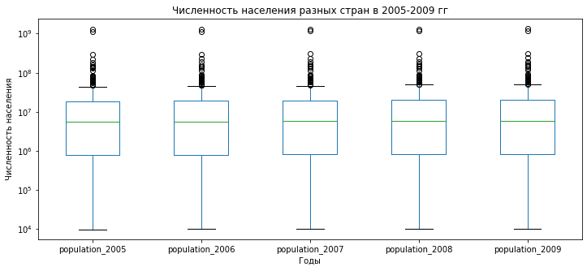

```python
fig, axes = plt.subplots(figsize=(12,5))
population.plot(kind='box',
#                 logy=True,
                logy='sym',
                ax=axes)
plt.title(f'Численность населения разных стран в 2005-2009 гг')
plt.ylabel('Численность населения')
plt.xlabel('Годы')
plt.show()
```

```python
population.describe()
```

|  | population_2005 | population_2006 | population_2007 | population_2008 | population_2009 |
| --- | --- | --- | --- | --- | --- |
| count | 2.130000e+02 | 2.130000e+02 | 2.130000e+02 | 2.130000e+02 | 2.130000e+02 |
| mean | 3.036288e+07 | 3.072761e+07 | 3.109222e+07 | 3.146240e+07 | 3.183336e+07 |
| std | 1.220724e+08 | 1.232291e+08 | 1.243538e+08 | 1.254669e+08 | 1.265691e+08 |
| min | 9.694000e+03 | 9.732000e+03 | 9.764000e+03 | 9.788000e+03 | 9.808000e+03 |
| 25% | 7.765850e+05 | 7.875440e+05 | 7.986900e+05 | 8.101000e+05 | 8.218650e+05 |
| 50% | 5.419432e+06 | 5.524927e+06 | 5.661000e+06 | 5.786000e+06 | 5.915000e+06 |
| 75% | 1.829039e+07 | 1.882613e+07 | 1.956148e+07 | 2.021700e+07 | 2.045000e+07 |
| max | 1.303720e+09 | 1.311020e+09 | 1.317885e+09 | 1.324655e+09 | 1.331260e+09 |

```python
population[population.population_2009 == population.population_2009.max()]
```

|  | country | population_2005 | population_2006 | population_2007 | population_2008 | population_2009 |
| --- | --- | --- | --- | --- | --- | --- |
| 39 | China | 1.303720e+09 | 1.311020e+09 | 1.317885e+09 | 1.324655e+09 | 1.331260e+09 |

Распределение кажется правдоподобным. У маленьких стран - небольшое население, максимальное население у Китая.

### Потребление электроэнергии (кВтч на душу населения)

Загрузим лист с информацией о потреблении электроэнергии.

```python
try:
    electric_power = pd.read_excel(
        path,
        sheet_name='Electric power consumption',
        header=0,
    )
except Exception as err:
    print('Ошибка чтения файла:', repr(err))
```

Посмотрим на первые строки таблицы.

```python
electric_power.head()
```

|  | Country name | 2005 | 2006 | 2007 | 2008 | 2009 |
| --- | --- | --- | --- | --- | --- | --- |
| 0 | Afghanistan | NaN | NaN | NaN | NaN | NaN |
| 1 | Algeria | 869.0 | 841.0 | 871.0 | 921.0 | 841.0 |
| 2 | American Samoa | NaN | NaN | NaN | NaN | NaN |
| 3 | Andorra | NaN | NaN | NaN | NaN | NaN |
| 4 | Angola | 128.0 | 170.0 | 157.0 | 204.0 | 225.0 |

А так же на всю имеющуюся информацию.

```python
electric_power.info()
```

```
<class 'pandas.core.frame.DataFrame'>
RangeIndex: 212 entries, 0 to 211
Data columns (total 6 columns):
 #   Column        Non-Null Count  Dtype
---  ------        --------------  -----
 0   Country name  212 non-null    object
 1   2005          134 non-null    float64
 2   2006          135 non-null    float64
 3   2007          135 non-null    float64
 4   2008          134 non-null    float64
 5   2009          133 non-null    float64
dtypes: float64(5), object(1)
memory usage: 10.1+ KB
```

Таблица представлена 212 строками, каждая из которых является информацией об изменении электропотребления отдельной страны и 6 колонками с информацией о названии страны и энергопотреблении в 2005-2009 годах.

В таблице есть пропуски.

Оценим количество пропусков в данных.

```python
def display_missing(data):
    try:
        display(data.stb.missing(style=True))
    except Exception as err:
        try:
            display(data.isna().sum())
        except Exception as err:
            print('Ошибка чтения файла df:', repr(err))
```

```python
display_missing(electric_power)
```

|  | missing | total | percent |
| --- | --- | --- | --- |
| 2009 | 79 | 212 | 37.26% |
| 2005 | 78 | 212 | 36.79% |
| 2008 | 78 | 212 | 36.79% |
| 2006 | 77 | 212 | 36.32% |
| 2007 | 77 | 212 | 36.32% |
| Country name | 0 | 212 | 0.00% |

Так как в названии страны пропусков нет, а мы планируем объединить данные в финальной таблице, то нет смысла от них избавляться.

Приведем названия колонок к более удобному виду.

```python
rename_columns(electric_power, 'electric_power_')
```

Проверим таблицу на дубликаты.

```python
electric_power.duplicated().sum(), electric_power.country.duplicated().sum()
```

```
(0, 0)
```

Дубликатов нет.

У нас есть данные всего по пяти годам, так что если в строке со значениями у нас будут пропуски, это затруднит анализ данных. В данном датасете после ознакомления с данными с пропусками было решено оставить только те строчки, в которых заполнена информация по всем годам.

```python
electric_power.dropna(thresh=6, inplace=True)
```

Оценим качество данных.

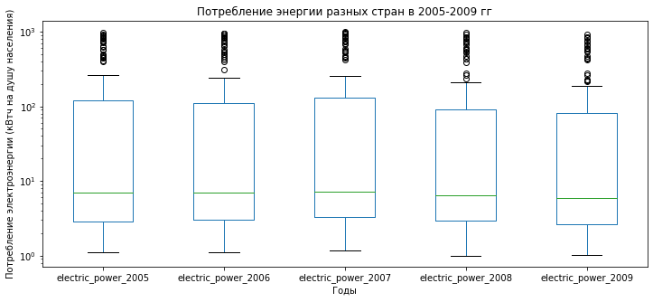

```python
fig, axes = plt.subplots(figsize=(12,5))
electric_power.plot(kind='box',
                    logy=True,
                    ax=axes)
plt.title(f'Потребление энергии разных стран в 2005-2009 гг')
plt.ylabel('Потребление электроэнергии (кВтч на душу населения)')
plt.xlabel('Годы')
plt.show()
```

Распределение выглядит реалистично, сразу видим уменьшение разброса энергопотребления в 2008 и особенно в 2009 году после кризиса.

Объединим таблицы.

```python
df = population.merge(
    electric_power,
    left_on='country',
    right_on='country',
    how='outer'
)
```

```python
df.head()
```

|  | country | population_2005 | population_2006 | population_2007 | population_2008 | population_2009 | electric_power_2005 | electric_power_2006 | electric_power_2007 | electric_power_2008 | electric_power_2009 |
| --- | --- | --- | --- | --- | --- | --- | --- | --- | --- | --- | --- |
| 0 | Afghanistan | 24860855.0 | 25631282.0 | 26349243.0 | 27032197.0 | 27708187.0 | NaN | NaN | NaN | NaN | NaN |
| 1 | Albania | 2992724.0 | 2968028.0 | 2940880.0 | 2912559.0 | 2884303.0 | NaN | NaN | NaN | NaN | NaN |
| 2 | Algeria | 33960903.0 | 34507214.0 | 35097043.0 | 35725377.0 | 36383302.0 | 869.0 | 841.0 | 871.0 | 921.0 | 841.0 |
| 3 | American Samoa | 59117.0 | 58652.0 | 57919.0 | 57053.0 | 56245.0 | NaN | NaN | NaN | NaN | NaN |
| 4 | Andorra | 81223.0 | 81877.0 | 81292.0 | 79969.0 | 78659.0 | NaN | NaN | NaN | NaN | NaN |

Ввиду того, что не по каждой стране есть информация и численности населения, и об уровне электропотребления, в таблице наблюдаем пропуски.

### Импорт энергии, нетто (% от потребления энергии)

Загрузим лист с информацией об импорте энергии.

```python
try:
    energy_imports = pd.read_excel(
        path,
        sheet_name='Energy imports',
        header=0,
    )
except Exception as err:
    print('Ошибка чтения файла:', repr(err))
```

Посмотрим на первые строки таблицы.

```python
energy_imports.head()
```

|  | Country name | 2005 | 2006 | 2007 | 2008 | 2009 |
| --- | --- | --- | --- | --- | --- | --- |
| 0 | Afghanistan | NaN | NaN | NaN | NaN | NaN |
| 1 | Albania | 48.0 | 41.0 | 48.0 | 44.0 | 39.0 |
| 2 | Algeria | -415.0 | -376.0 | -347.0 | -333.0 | -275.0 |
| 3 | American Samoa | NaN | NaN | NaN | NaN | NaN |
| 4 | Andorra | NaN | NaN | NaN | NaN | NaN |

А так же на всю имеющуюся информацию.

```python
energy_imports.info()
```

```
<class 'pandas.core.frame.DataFrame'>
RangeIndex: 213 entries, 0 to 212
Data columns (total 6 columns):
 #   Column        Non-Null Count  Dtype
---  ------        --------------  -----
 0   Country name  213 non-null    object
 1   2005          136 non-null    float64
 2   2006          136 non-null    float64
 3   2007          136 non-null    float64
 4   2008          136 non-null    float64
 5   2009          136 non-null    float64
dtypes: float64(5), object(1)
memory usage: 10.1+ KB
```

Таблица представлена 213 строками, каждая из которых является информацией об импорте энергии отдельной страны и 6 колонками с информацией о названии страны и энергоиморте в 2005-2009 годах.

В таблице есть пропуски.

Так как в названии страны пропусков нет, а мы планируем объединить данные в финальной таблице, то нет смысла от них избавляться.

Приведем названия колонок к более удобному для дальшейшей работы виду.

```python
rename_columns(energy_imports, 'energy_imports_')
```

Проверим таблицу на дубликаты.

```python
energy_imports.duplicated().sum(), energy_imports.country.duplicated().sum()
```

```
(0, 0)
```

Дубликатов нет.

Оставим только строки без пропусков.

```python
energy_imports.dropna(thresh=6, inplace=True)
```

```python
energy_imports.info()
```

```
<class 'pandas.core.frame.DataFrame'>
Int64Index: 136 entries, 1 to 212
Data columns (total 6 columns):
 #   Column               Non-Null Count  Dtype
---  ------               --------------  -----
 0   country              136 non-null    object
 1   energy_imports_2005  136 non-null    float64
 2   energy_imports_2006  136 non-null    float64
 3   energy_imports_2007  136 non-null    float64
 4   energy_imports_2008  136 non-null    float64
 5   energy_imports_2009  136 non-null    float64
dtypes: float64(5), object(1)
memory usage: 7.4+ KB
```

Оценим качество данных.

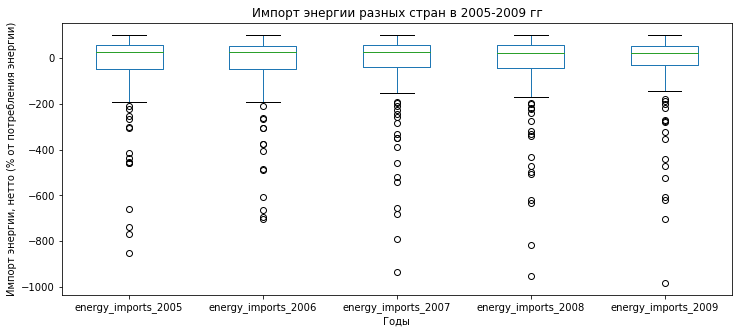

```python
fig, axes = plt.subplots(figsize=(12,5))
energy_imports.plot(kind='box',
#                     logy='sym',
                    ax=axes)
plt.title(f'Импорт энергии разных стран в 2005-2009 гг')
plt.ylabel('Импорт энергии, нетто (% от потребления энергии)')
plt.xlabel('Годы')
plt.show()
```

Чистый импорт энергии оценивается как потребление энергии за вычетом производимой энергии, что измеряется в нефтяном эквиваленте. Отрицательное значение указывает на то, что страна является [нетто-экспортером](https://knoema.ru/atlas/ranks/Импорт-энергии).

Распределение кажется реалистичным. Некоторые нетто-экспортеры после кризиса увеличили экспорт, а некотоые - сократили.

Объединим таблицы.

```python
df = df.merge(
    energy_imports,
    left_on='country',
    right_on='country',
    how='outer'
)
```

### Коэффициент рождаемости, сырой (на 1000 человек)

Загрузим лист с информацией о коэффициенте рождаемости.

```python
try:
    birth_rate = pd.read_excel(
        path,
        sheet_name='Birth rate',
        header=0,
    )
except Exception as err:
    print('Ошибка чтения файла:', repr(err))
```

Посмотрим на первые строки таблицы.

```python
birth_rate.head()
```

|  | Country name | 2005 | 2006 | 2007 | 2008 | 2009 |
| --- | --- | --- | --- | --- | --- | --- |
| 0 | Afghanistan | 45.0 | 44.0 | 42.0 | 41.0 | 39.0 |
| 1 | Albania | 14.0 | 14.0 | 13.0 | 13.0 | 13.0 |
| 2 | Algeria | 21.0 | 22.0 | 23.0 | 24.0 | 24.0 |
| 3 | American Samoa | NaN | 22.0 | NaN | NaN | NaN |
| 4 | Andorra | 11.0 | 11.0 | 10.0 | 10.0 | 10.0 |

А так же на всю имеющуюся информацию.

```python
birth_rate.info()
```

```
<class 'pandas.core.frame.DataFrame'>
RangeIndex: 213 entries, 0 to 212
Data columns (total 6 columns):
 #   Column        Non-Null Count  Dtype
---  ------        --------------  -----
 0   Country name  213 non-null    object
 1   2005          202 non-null    float64
 2   2006          204 non-null    float64
 3   2007          204 non-null    float64
 4   2008          201 non-null    float64
 5   2009          201 non-null    float64
dtypes: float64(5), object(1)
memory usage: 10.1+ KB
```

Таблица представлена 213 строками, каждая из которых является информацией о коэффициенте рождаемости отдельной страны и 6 колонками с информацией о названии страны и рождаемости в 2005-2009 годах.

В таблице есть пропуски.

Так как в названии страны пропусков нет, а мы планируем объединить данные в финальной таблице, то нет смысла от них избавляться.

Приведем названия колонок к более удобному для дальшейшей работы виду.

```python
rename_columns(birth_rate, 'birth_rate_')
```

Проверим таблицу на дубликаты.

```python
birth_rate.duplicated().sum(), birth_rate.country.duplicated().sum()
```

```
(0, 0)
```

Дубликатов нет.

Избавимся от пропусков.

```python
birth_rate.dropna(thresh=6, inplace=True)
```

Оценим качество данных.

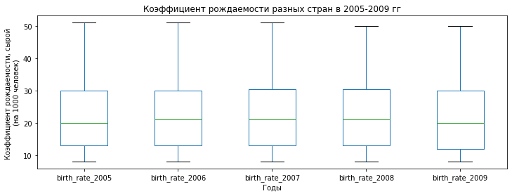

```python
fig, axes = plt.subplots(figsize=(12,4))
birth_rate.plot(kind='box',
#                     logy=True,
                    ax=axes)
plt.title(f'Коэффициент рождаемости разных стран в 2005-2009 гг')
plt.ylabel('Коэффициент рождаемости, сырой \n(на 1000 человек)')
plt.xlabel('Годы')
plt.show()
```

Распределение выглядит реалистично.

Объединим таблицы.

```python
df = df.merge(
    birth_rate,
    left_on='country',
    right_on='country',
    how='outer'
)
```

### Количество интернет-пользователей (на 100 человек)

Загрузим лист с информацией о количестве интернет-пользователей.

```python
try:
    internet_users = pd.read_excel(
        path,
        sheet_name='Internet users',
        header=0,
    )
except Exception as err:
    print('Ошибка чтения файла:', repr(err))
```

Посмотрим на первые строки таблицы.

```python
internet_users.head()
```

|  | Country name | 2005 | 2006 | 2007 | 2008 | 2009 |
| --- | --- | --- | --- | --- | --- | --- |
| 0 | Afghanistan | 1.2 | 2.1 | 1.9 | 1.8 | 3.6 |
| 1 | Albania | 6.0 | 9.6 | 15.0 | 23.9 | 41.2 |
| 2 | Algeria | 5.8 | 7.4 | 9.5 | 10.2 | 11.2 |
| 3 | American Samoa | NaN | NaN | NaN | NaN | NaN |
| 4 | Andorra | 37.6 | 48.9 | 70.9 | 70.0 | 78.5 |

А так же на всю имеющуюся информацию.

```python
internet_users.info()
```

```
<class 'pandas.core.frame.DataFrame'>
RangeIndex: 213 entries, 0 to 212
Data columns (total 6 columns):
 #   Column        Non-Null Count  Dtype
---  ------        --------------  -----
 0   Country name  213 non-null    object
 1   2005          197 non-null    float64
 2   2006          196 non-null    float64
 3   2007          203 non-null    float64
 4   2008          202 non-null    float64
 5   2009          201 non-null    float64
dtypes: float64(5), object(1)
memory usage: 10.1+ KB
```

Таблица представлена 213 строками, каждая из которых является информацией о количестве интернет-пользователей отдельной страны и 6 колонками с информацией о названии страны и количестве интернет-пользователей в 2005-2009 годах.

В таблице есть пропуски.

Так как в названии страны пропусков нет, а мы планируем объединить данные в финальной таблице, то нет смысла от них избавляться.

Приведем названия колонок к более удобному для дальшейшей работы виду.

```python
rename_columns(internet_users, 'internet_users_')
```

Проверим таблицу на дубликаты.

```python
internet_users.duplicated().sum(), internet_users.country.duplicated().sum()
```

```
(0, 0)
```

Дубликатов нет.

Избавимся от пропусков.

```python
internet_users.dropna(thresh=6, inplace=True)
```

Оценим качество данных.

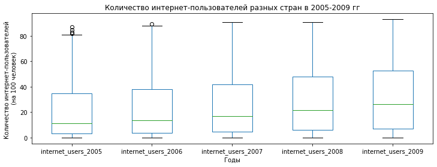

```python
fig, axes = plt.subplots(figsize=(12,4))
internet_users.plot(kind='box',
#                     logy=True,
                    ax=axes)
plt.title(f'Количество интернет-пользователей разных стран в 2005-2009 гг')
plt.ylabel('Количество интернет-пользователей \n (на 100 человек)')
plt.xlabel('Годы')
plt.show()
```

Количество интернет-пользователей росло с каждым годом. Распределение выглядит реалистичным.

Объединим таблицы.

```python
df = df.merge(
    internet_users,
    left_on='country',
    right_on='country',
    how='outer'
)
```

### Выбросы $CO_2$ (метрические тонны на душу населения)

Загрузим лист с информацией о выбросах углекислого газа.

```python
try:
    co2_emission = pd.read_excel(
        path,
        sheet_name='CO2 emissions',
        header=0,
    )
except Exception as err:
    print('Ошибка чтения файла:', repr(err))
```

Посмотрим на первые строки таблицы.

```python
co2_emission.head()
```

|  | Country name | 2005 | 2006 | 2007 | 2008 | 2009 |
| --- | --- | --- | --- | --- | --- | --- |
| 0 | Afghanistan | 0.0 | 0.1 | 0.1 | 0.1 | 0.2 |
| 1 | Albania | 1.4 | 1.3 | 1.4 | 1.4 | 1.3 |
| 2 | Algeria | 3.2 | 3.0 | 3.2 | 3.2 | 3.4 |
| 3 | American Samoa | NaN | NaN | NaN | NaN | NaN |
| 4 | Andorra | 7.1 | 6.7 | 6.6 | 6.7 | 6.6 |

А так же на всю имеющуюся информацию.

```python
co2_emission.info()
```

```
<class 'pandas.core.frame.DataFrame'>
RangeIndex: 213 entries, 0 to 212
Data columns (total 6 columns):
 #   Column        Non-Null Count  Dtype
---  ------        --------------  -----
 0   Country name  213 non-null    object
 1   2005          196 non-null    float64
 2   2006          197 non-null    float64
 3   2007          198 non-null    float64
 4   2008          198 non-null    float64
 5   2009          198 non-null    float64
dtypes: float64(5), object(1)
memory usage: 10.1+ KB
```

Таблица представлена 213 строками, каждая из которых является информацией о количестве выбросах угрекислого газа отдельной страны и 6 колонками с информацией о названии страны и количестве выбросов в 2005-2009 годах.

В таблице есть пропуски.

Так как в названии страны пропусков нет, а мы планируем объединить данные в финальной таблице, то нет смысла от них избавляться.

Приведем названия колонок к более удобному для дальшейшей работы виду.

```python
rename_columns(co2_emission, 'co2_')
```

Проверим таблицу на дубликаты.

```python
co2_emission.duplicated().sum(), co2_emission.country.duplicated().sum()
```

```
(0, 0)
```

Дубликатов нет.

Избавимся от пропусков.

```python
co2_emission.dropna(thresh=6, inplace=True)
```

Оценим качество данных.

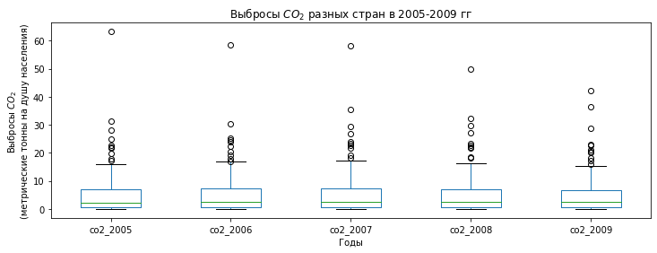

```python
fig, axes = plt.subplots(figsize=(12,4))
co2_emission.plot(kind='box',
#                     logy=True,
                    ax=axes)
plt.title(f'Выбросы $CO_2$ разных стран в 2005-2009 гг')
plt.ylabel('Выбросы $CO_2$ \n(метрические тонны на душу населения)')
plt.xlabel('Годы')
plt.show()
```

Распределение выглядит реалистично, выбросы углекислого газа после кризиса сократились.

Объединим таблицы.

```python
df = df.merge(
    co2_emission,
    left_on='country',
    right_on='country',
    how='outer'
)
```

### Налоговые поступления (% от ВВП)

Загрузим лист с информацией о налоговых поступлениях.

```python
try:
    tax_revenue = pd.read_excel(
        path,
        sheet_name='Tax revenue',
        header=0,
    )
except Exception as err:
    print('Ошибка чтения файла:', repr(err))
```

Посмотрим на первые строки таблицы.

```python
tax_revenue.head()
```

|  | Country name | 2005 | 2006 | 2007 | 2008 | 2009 |
| --- | --- | --- | --- | --- | --- | --- |
| 0 | Afghanistan | NaN | 6.9 | 5.2 | 6.0 | 8.4 |
| 1 | Albania | NaN | NaN | NaN | NaN | NaN |
| 2 | Algeria | NaN | 40.8 | 37.4 | 45.3 | 35.1 |
| 3 | American Samoa | NaN | NaN | NaN | NaN | NaN |
| 4 | Andorra | NaN | NaN | NaN | NaN | NaN |

А так же на всю имеющуюся информацию.

```python
tax_revenue.info()
```

```
<class 'pandas.core.frame.DataFrame'>
RangeIndex: 213 entries, 0 to 212
Data columns (total 6 columns):
 #   Column         Non-Null Count  Dtype
---  ------         --------------  -----
 0   Country name   213 non-null    object
 1   2005           122 non-null    float64
 2   2006           127 non-null    float64
 3   2007           131 non-null    float64
 4   2008           134 non-null    float64
 5   2009           133 non-null    float64
dtypes: float64(5), object(1)
memory usage: 10.1+ KB
```

Таблица представлена 213 строками, каждая из которых является информацией о количестве налоговых поступлений отдельной страны и 6 колонками с информацией о названии страны и количестве поступлений в 2005-2009 годах.

В таблице есть пропуски.

Так как в названии страны пропусков нет, а мы планируем объединить данные в финальной таблице, то нет смысла от них избавляться.

Приведем названия колонок к более удобному для дальшейшей работы виду.

```python
rename_columns(tax_revenue, 'tax_revenue_')
```

Проверим таблицу на дубликаты.

```python
tax_revenue.duplicated().sum(), tax_revenue.country.duplicated().sum()
```

```
(0, 0)
```

Дубликатов нет.

Избавимся от пропусков. В данной колонке достаточно много пропусков. Поэтому было решено не откидывать те данные, в которых пропуск есть, например, в 2005 или 2006 году - так мы всё равно сможем оценить влияние кризиса 2008 года.

```python
tax_revenue.dropna(subset=['tax_revenue_2007', 'tax_revenue_2008', 'tax_revenue_2009'], thresh=3, inplace=True)
```

Оценим качество данных.

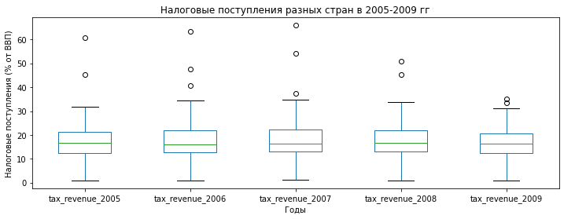

```python
fig, axes = plt.subplots(figsize=(12,4))
tax_revenue.plot(kind='box',
#                     logy=True,
                    ax=axes)
plt.title(f'Налоговые поступления разных стран в 2005-2009 гг')
plt.ylabel('Налоговые поступления (% от ВВП)')
plt.xlabel('Годы')
plt.show()
```

Распределение выглядит реалистичным. Видим, что налоговые поступления после кризиса 2008 года сократились.

Объединим таблицы.

```python
df = df.merge(
    tax_revenue,
    left_on='country',
    right_on='country',
    how='outer'
)
```

### ВВП (в текущих долларах США)

Загрузим лист с информацией о ВВП.

```python
try:
    gdp = pd.read_excel(
        path,
        sheet_name='GDP',
        header=0,
    )
except Exception as err:
    print('Ошибка чтения файла:', repr(err))
```

Посмотрим на первые строки таблицы.

```python
gdp.head()
```

|  | Country name | 2005 | 2006 | 2007 | 2008 | 2009 |
| --- | --- | --- | --- | --- | --- | --- |
| 0 | Afghanistan | 6,275,076,016.5 | 7,057,597,614.5 | 9,843,851,009.4 | 10,190,534,636.6 | 12,486,950,468.2 |
| 1 | Albania | 8,376,483,393.9 | 9,132,558,096.9 | 10,701,011,524.1 | 12,881,353,507.9 | 12,044,208,085.9 |
| 2 | Algeria | 103,198,650,297.8 | 117,026,655,313.7 | 134,977,867,931.6 | 171,000,162,581.5 | 137,211,795,394.2 |
| 3 | American Samoa | NaN | NaN | NaN | NaN | NaN |
| 4 | Andorra | 2,539,759,285.9 | 2,823,503,852.6 | 3,245,411,583.7 | 3,712,034,266.5 | NaN |

А так же на всю имеющуюся информацию.

```python
gdp.info()
```

```
<class 'pandas.core.frame.DataFrame'>
RangeIndex: 213 entries, 0 to 212
Data columns (total 6 columns):
 #   Column        Non-Null Count  Dtype
---  ------        --------------  -----
 0   Country name  213 non-null    object
 1   2005          198 non-null    object
 2   2006          198 non-null    object
 3   2007          198 non-null    object
 4   2008          197 non-null    object
 5   2009          195 non-null    object
dtypes: object(6)
memory usage: 10.1+ KB
```

Таблица с информацией о ВВП представлена 213 строчками, в каждой из которой содержится значения ВВП для страны, и шестью колонками: названия стран и ВВП за 2005-2009 годы.

Сразу стоит отметить, что данные загрузилились в строковом формате.

Приведем названия колонок к более удобному для дальшейшей работы виду.

```python
rename_columns(gdp, 'gdp_')
```

Заменим строковый формат данных на числовой.

```python
to_float(gdp)
```

```python
gdp.head()
```

|  | country | gdp_2005 | gdp_2006 | gdp_2007 | gdp_2008 | gdp_2009 |
| --- | --- | --- | --- | --- | --- | --- |
| 0 | Afghanistan | 6.275076e+09 | 7.057598e+09 | 9.843851e+09 | 1.019053e+10 | 1.248695e+10 |
| 1 | Albania | 8.376483e+09 | 9.132558e+09 | 1.070101e+10 | 1.288135e+10 | 1.204421e+10 |
| 2 | Algeria | 1.031987e+11 | 1.170267e+11 | 1.349779e+11 | 1.710002e+11 | 1.372118e+11 |
| 3 | American Samoa | NaN | NaN | NaN | NaN | NaN |
| 4 | Andorra | 2.539759e+09 | 2.823504e+09 | 3.245412e+09 | 3.712034e+09 | NaN |

Проверим таблицу на дубликаты.

```python
gdp.duplicated().sum(), gdp.country.duplicated().sum()
```

```
(0, 0)
```

Дубликатов нет.

Избавимся от пропусков.

```python
gdp.dropna(
#     subset=['gdp_2007', 'gdp_2008', 'gdp_2009'],
    thresh=6,
    inplace=True
)
```

Оценим качество данных.

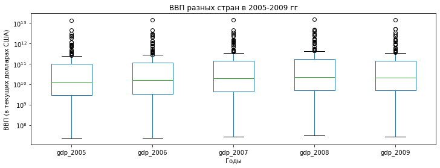

```python
fig, axes = plt.subplots(figsize=(12,4))
gdp.plot(kind='box',
                    logy='sym',
                    ax=axes)
plt.title(f'ВВП разных стран в 2005-2009 гг')
plt.ylabel('ВВП (в текущих долларах США)')
plt.xlabel('Годы')
plt.show()
```

Распределение кажется реалистичным.

Объединим таблицы.

```python
df = df.merge(
    gdp,
    left_on='country',
    right_on='country',
    how='outer'
)
```

### Сельское хозяйство, добавленная стоимость (% от ВВП)

Добавленная стоимость в сельском хозяйстве на одного работника показывает производительность в данной отрасли. Она измеряется как стоимость произведённого в сельскохозяйственном секторе объёма продукции за вычетом себестоимости. Сельское хозяйство включает лесное хозяйство, охотничье дело, рыболовство, а также выращивание сельскохозяйственных культур и животноводство.

Загрузим лист с информацией о добавленной стоимости в сельском хозяйстве.

```python
try:
    agriculture = pd.read_excel(
        path,
        sheet_name='Agriculture, value added',
        header=0,
    )
except Exception as err:
    print('Ошибка чтения файла:', repr(err))
```

Посмотрим на первые строки таблицы.

```python
agriculture.head()
```

|  | Country name | 2005 | 2006 | 2007 | 2008 | 2009 |
| --- | --- | --- | --- | --- | --- | --- |
| 0 | Afghanistan | 31.8 | 29.2 | 30.6 | 25.4 | 30.2 |
| 1 | Albania | 22.8 | 22.0 | 20.7 | 19.4 | 19.4 |
| 2 | Algeria | 8.0 | 7.7 | 7.7 | 6.7 | 9.5 |
| 3 | American Samoa | NaN | NaN | NaN | NaN | NaN |
| 4 | Andorra | NaN | NaN | NaN | NaN | NaN |

А так же на всю имеющуюся информацию.

```python
agriculture.info()
```

```
<class 'pandas.core.frame.DataFrame'>
RangeIndex: 213 entries, 0 to 212
Data columns (total 6 columns):
 #   Column         Non-Null Count  Dtype
---  ------         --------------  -----
 0   Country name   213 non-null    object
 1   2005           178 non-null    float64
 2   2006           179 non-null    float64
 3   2007           179 non-null    float64
 4   2008           175 non-null    float64
 5   2009           173 non-null    float64
dtypes: float64(5), object(1)
memory usage: 10.1+ KB
```

Таблица с информацией о сельском хозяйстве представлена 213 строчками, в каждой из которой содержится значения добавленной стоимости для страны, и шестью колонками: названия стран и добавленная стоимость за 2005-2009 годы.

Приведем названия колонок к более удобному для дальшейшей работы виду.

```python
rename_columns(agriculture, 'agriculture_')
```

Проверим таблицу на дубликаты.

```python
agriculture.duplicated().sum(), agriculture.country.duplicated().sum()
```

```
(0, 0)
```

Дубликатов нет.

Избавимся от пропусков.

```python
agriculture.dropna(
#     subset=['agriculture_2007', 'agriculture_2008', 'agriculture_2009'],
    thresh=6,
    inplace=True
)
```

Оценим качество данных.

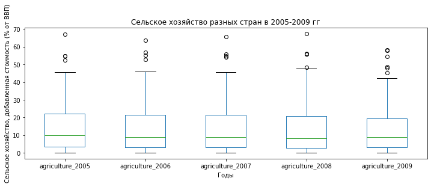

```python
fig, axes = plt.subplots(figsize=(12,4))
agriculture.plot(kind='box',
#                     logy=True,
                    ax=axes)
plt.title(f'Сельское хозяйство разных стран в 2005-2009 гг')
plt.ylabel('Сельское хозяйство, добавленная стоимость (% от ВВП)')
plt.xlabel('Годы')
plt.show()
```

Распределение кажется реалистичным, добавленная стоимость сельского хозяйства сократилась в 2009 году.

Объединим таблицы.

```python
df = df.merge(
    agriculture,
    left_on='country',
    right_on='country',
    how='outer'
)
```

### Валовые сбережения (% от ВВП)

Загрузим лист с информацией о валовых сбережениях.

```python
try:
    gross_savings = pd.read_excel(
        path,
        sheet_name='Gross savings',
        header=0,
    )
except Exception as err:
    print('Ошибка чтения файла:', repr(err))
```

Посмотрим на первые строки таблицы.

```python
gross_savings.head()
```

|  | Country name | 2005 | 2006 | 2007 | 2008 | 2009 |
| --- | --- | --- | --- | --- | --- | --- |
| 0 | Afghanistan | NaN | NaN | NaN | -16.0 | -9.0 |
| 1 | Albania | 17.0 | 17.0 | 20.0 | 20.0 | 20.0 |
| 2 | Algeria | 52.0 | 55.0 | 57.0 | 57.0 | 47.0 |
| 3 | American Samoa | NaN | NaN | NaN | NaN | NaN |
| 4 | Andorra | NaN | NaN | NaN | NaN | NaN |

А так же на всю имеющуюся информацию.

```python
gross_savings.info()
```

```
<class 'pandas.core.frame.DataFrame'>
RangeIndex: 213 entries, 0 to 212
Data columns (total 6 columns):
 #   Column        Non-Null Count  Dtype
---  ------        --------------  -----
 0   Country name  213 non-null    object
 1   2005          161 non-null    float64
 2   2006          159 non-null    float64
 3   2007          158 non-null    float64
 4   2008          157 non-null    float64
 5   2009          154 non-null    float64
dtypes: float64(5), object(1)
memory usage: 10.1+ KB
```

Таблица с информацией о валовых сбережениях представлена 213 строчками, в каждой из которой содержится значения валовых сбережений для страны, и шестью колонками: названия стран и валовые сбережения за 2005-2009 годы.

Приведем названия колонок к более удобному для дальшейшей работы виду.

```python
rename_columns(gross_savings, 'gross_savings_')
```

Проверим таблицу на дубликаты.

```python
gross_savings.duplicated().sum(), gross_savings.country.duplicated().sum()
```

```
(0, 0)
```

Дубликатов нет.

Избавимся от пропусков. Для валовых сбережений тоже многовато пропусков, оставим все значения, где данные есть хотя бы за 2007-2009 год.

```python
gross_savings.dropna(
    subset=['gross_savings_2007', 'gross_savings_2008', 'gross_savings_2009'],
    thresh=3,
    inplace=True
)
```

Оценим качество данных.

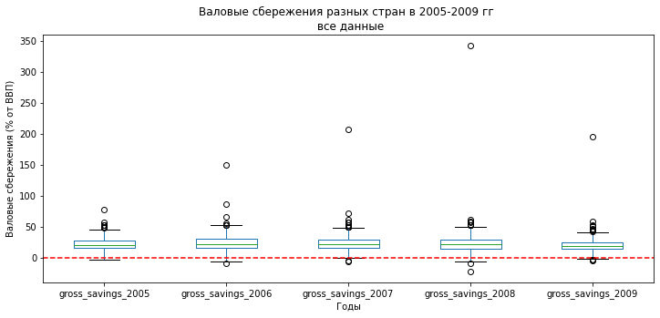

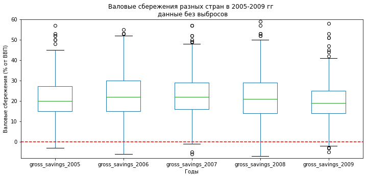

```python
fig, axes = plt.subplots(figsize=(12,5))
gross_savings.plot(kind='box',
#                     logy='sym',
                    ax=axes
                  )
plt.title(f'Валовые сбережения разных стран в 2005-2009 гг \n все данные')
plt.ylabel('Валовые сбережения (% от ВВП)')
plt.xlabel('Годы')
# plt.ylim(-5, 50)
plt.axhline(y=0, color='r', linestyle='--')
plt.show()

fig, axes = plt.subplots(figsize=(12,5))
gross_savings.plot(kind='box',
#                     logy=True,
                    ax=axes
                  )
plt.title(f'Валовые сбережения разных стран в 2005-2009 гг \n данные без выбросов')
plt.ylabel('Валовые сбережения (% от ВВП)')
plt.xlabel('Годы')
plt.ylim(-8, 60)
plt.axhline(y=0, color='r', linestyle='--')
plt.show()
```

```python
gross_savings.describe()
```

|  | gross_savings_2005 | gross_savings_2006 | gross_savings_2007 | gross_savings_2008 | gross_savings_2009 |
| --- | --- | --- | --- | --- | --- |
| count | 148.000000 | 151.000000 | 153.000000 | 153.000000 | 153.000000 |
| mean | 22.344595 | 24.139073 | 24.620915 | 23.836601 | 21.130719 |
| std | 12.302709 | 17.115700 | 19.505737 | 29.126642 | 18.118286 |
| min | -3.000000 | -10.000000 | -6.000000 | -22.000000 | -5.000000 |
| 25% | 15.000000 | 15.000000 | 16.000000 | 14.000000 | 14.000000 |
| 50% | 20.000000 | 22.000000 | 22.000000 | 21.000000 | 19.000000 |
| 75% | 27.250000 | 30.000000 | 29.000000 | 29.000000 | 25.000000 |
| max | 77.000000 | 149.000000 | 207.000000 | 342.000000 | 195.000000 |

```python
gross_savings[gross_savings.gross_savings_2009 == gross_savings.gross_savings_2009.max()]
```

|  | country | gross_savings_2005 | gross_savings_2006 | gross_savings_2007 | gross_savings_2008 | gross_savings_2009 |
| --- | --- | --- | --- | --- | --- | --- |
| 189 | Timor-Leste | NaN | 149.0 | 207.0 | 342.0 | 195.0 |

Восточный Тимор - Наш лидер по валовым сбережениям в % от ВВП — слаборазвитое [аграрное государство](https://ru.wikipedia.org/wiki/Восточный_Тимор#Экономика). Экономика страны была разрушена в ходе гражданской войны 1976—1999 гг. Её основу составляло сельское хозяйство, в котором преобладало орошаемое земледелие. Половина населения не имела работы. С обретением независимости на первый план вышла нефте- и газодобыча на морском шельфе, которые осуществляются при помощи австралийских компаний. Экономика страны после получения независимости развивается достаточно успешно.

Такие высокие показатели значений говорят о том, что страна боится вкладывать деньги в экономику и они просто лежат, развития экономики нет.

Валовые сбережения, близкие к нулю или не высокие при высоком ВВП это показатель того что деньги вложены и работают на экономику.

Для сравнения взглянем на Соединенные Штаты.

```python
gross_savings[gross_savings['country'] == 'United States']
```

|  | country | gross_savings_2005 | gross_savings_2006 | gross_savings_2007 | gross_savings_2008 | gross_savings_2009 |
| --- | --- | --- | --- | --- | --- | --- |
| 202 | United States | 18.0 | 18.0 | 18.0 | 16.0 | 14.0 |

Распределение кажется реалистичным. Валовые сбережения некоторых стран ушли в зону ниже нуля в 2008 году, среднее и медианное значения валовых сбережений снизились после 2008 года.

Объединим таблицы.

```python
df = df.merge(
    gross_savings,
    left_on='country',
    right_on='country',
    how='outer'
)
```

Теперь, когда мы знаем, по каким странам у нас есть данные, следует дополнить сводную таблицу данными про регионы стран.

### Регионы

Загрузим лист с информацией о регионах.

```python
try:
    regions = pd.read_excel(
        path,
        sheet_name='Regions',
        header=0,
        usecols=['Name', 'Region'],
    )
except Exception as err:
    print('Ошибка чтения файла:', repr(err))
```

Посмотрим на первые строки таблицы.

```python
regions.head(10)
```

|  | Name | Region |
| --- | --- | --- |
| 0 | NaN | NaN |
| 1 | Afghanistan | South-Central Asia |
| 2 | Albania | Southern Europe |
| 3 | Algeria | Northern Africa |
| 4 | American Samoa | Polynesia, Oceania |
| 5 | Andorra | Southern Europe |
| 6 | Angola | Central Africa |
| 7 | Anguilla | Leeward Islands, Caribbean |
| 8 | Antarctica | Antarctica |
| 9 | Antigua and Barbuda | Leeward Islands, Caribbean |

А так же на всю имеющуюся информацию.

```python
regions.info()
```

```
<class 'pandas.core.frame.DataFrame'>
RangeIndex: 292 entries, 0 to 291
Data columns (total 2 columns):
 #   Column  Non-Null Count  Dtype
---  ------  --------------  -----
 0   Name    241 non-null    object
 1   Region  241 non-null    object
dtypes: object(2)
memory usage: 4.7+ KB
```

Данная таблица представлена 292 строками и 2 колонками с информацией о стрене и регионе, к которому она приурочена.

```python
display_missing(regions)
```

|  | missing | total | percent |
| --- | --- | --- | --- |
| Name | 51 | 292 | 17.47% |
| Region | 51 | 292 | 17.47% |

Видим, что таблица разрежена.

Приведем названия колонок к более удобному для дальшейшей работы виду.

```python
regions.columns = ['country', 'region']
regions = regions.dropna().reset_index(drop=True)

country_without_commas(regions)
```

```python
regions.head(10)
```

|  | country | region |
| --- | --- | --- |
| 0 | Afghanistan | South-Central Asia |
| 1 | Albania | Southern Europe |
| 2 | Algeria | Northern Africa |
| 3 | American Samoa | Polynesia, Oceania |
| 4 | Andorra | Southern Europe |
| 5 | Angola | Central Africa |
| 6 | Anguilla | Leeward Islands, Caribbean |
| 7 | Antarctica | Antarctica |
| 8 | Antigua and Barbuda | Leeward Islands, Caribbean |
| 9 | Argentina | Southern South America |

Оценим количество уникальных регионов, представленных в таблице.

```python
len(regions.region.unique())
```

```
56
```

```python
sorted(regions.region.unique())
```

```
['Africa, Middle East',
 'Antarctica',
 'Arabian Peninsula, Middle East',
 'Australia',
 'Caribbean',
 'Caribbean, parts of the Bahamas island chain.',
 'Caucasus, Western Asia',
 'Central Africa',
 'Central America',
 'Central Asia',
 'Central East South America',
 'Central Eastern South America',
 'Central South America',
 'East-Central Africa',
 'Eastern Africa',
 'Eastern Africa, African Great Lakes',
 'Eastern Asia',
 'Eastern Europe',
 'Eastern Europe - Northern Asia',
 'Greater Antilles, Caribbean',
 'Leeward Islands, Caribbean',
 'Lesser Antilles, Caribbean',
 'Maritime South-East Asia',
 'Maritime Southeast Asia, Melanesia, Oceania',
 'Mediterranean, Western Asia',
 'Melanesia, Oceania',
 'Micronesia, Oceania',
 'Middle East',
 'Middle East, Western Asia',
 'North America',
 'North Eastern South America',
 'North North America',
 'North West South America',
 'North-Eastern South America',
 'Northern Africa',
 'Northern Europe',
 'Northern South America',
 'Northern South America, Caribbean',
 'Oceania/Australia',
 'Oceania; Australia',
 'Polynesia, Oceania',
 'Region',
 'South-Central Asia',
 'South-East Asia',
 'South-East Asia, Australia',
 'Southeast Asia',
 'Southeastern Europe, Western Asia',
 'Southern Africa',
 'Southern Europe',
 'Southern Europe within Italy',
 'Southern South America',
 'Southern South America, Antarctic',
 'West Africa',
 'Western Asia',
 'Western Europe',
 'Western South America']
```

Достаточно подробное деление. И, к сожалению, абсолютно бесполезное. Если делать выводы по 213 странам, разделив их на 56 категорий, будет не очень информативно. Забудем о регионах. Вместо этого добавим к итоговой таблице информацию о континентах.

Напишем функцию, которая работает с библиотекой `pycountry_convert` и превращает названия стран в названия континентов.

```python
def country_to_continent(country_name):
    try:
        country_alpha2 = pc.country_name_to_country_alpha2(country_name)
        country_continent_code = pc.country_alpha2_to_continent_code(country_alpha2)
        country_continent_name = pc.convert_continent_code_to_continent_name(country_continent_code)
        return country_continent_name
    except Exception:
        return None
```

```python
df['country'] = df['country'].str.replace('St ', 'Saint ').str.replace('  ', ' ').str.replace('  ', ' ')
```

```python
df['continent'] = df['country'].apply(country_to_continent)
```

Посмотрим, все ли страны получили свой континент.

```python
df.continent.isna().sum()
```

```
23
```

Некоторые остались без континента, посмотрим, что с ними не так.

```python
df[df.continent.isna()]['country']
```

```
13                   Bahamas The
42                 Congo Dem Rep
43                     Congo Rep
45                 Cote d'Ivoire
48                       Curacao
56                Egypt Arab Rep
62                Faeroe Islands
68                    Gambia The
82           Hong Kong SAR China
87              Iran Islamic Rep
99                 Korea Dem Rep
100                    Korea Rep
101                       Kosovo
104                      Lao PDR
113              Macao SAR China
114                Macedonia FYR
125           Micronesia Fed Sts
167    Sint Maarten (Dutch part)
189                  Timor-Leste
206                 Venezuela RB
208        Virgin Islands (U S )
209           West Bank and Gaza
210                    Yemen Rep
Name: country, dtype: object
```

```python
country_to_continent('Rebublic Korea')
```

У них сложные названия. Придется дополнить функцию для распознавания континента. Теперь она возьмет все слова по отдельности, и если они не являются артиклями и частицами, попытается распознать континент.

```python
def by_word(country_name):
    for word in country_name.split():
        if len(word) > 3:
            name = country_to_continent(word)
            if name is not None:
                return name
    return None
```

Применим данную функцию только к тем странам, у которых в колонке с континентом пропуск.

```python
df['continent'] = df['continent'].where(~df['continent'].isna(), df['country'].apply(by_word))
```

```python
df.continent.isna().sum()
```

```
11
```

Осталось всего 11 стран без континента.

```python
df[df.continent.isna()]['country']
```

```
45                 Cote d'Ivoire
48                       Curacao
62                Faeroe Islands
99                 Korea Dem Rep
100                    Korea Rep
101                       Kosovo
104                      Lao PDR
167    Sint Maarten (Dutch part)
189                  Timor-Leste
208        Virgin Islands (U S )
209           West Bank and Gaza
Name: country, dtype: object
```

Далее, как бы ни хотелось автоматизировать этот процесс, возможно, будет проще просто заполнить оставшиеся пропуски вручную.

```python
def df_loc(place, continent):
    df.loc[place, 'continent'] = continent
```

```python
df_loc(45, 'Africa')
df_loc(48, 'North America')
df_loc(62, 'Europe')
df_loc(99, 'Asia')
df_loc(100, 'Asia')
df_loc(101, 'Europe')
df_loc(104, 'Asia')
df_loc(167, 'North America')
df_loc(189, 'Asia')
df_loc(208, 'North America')
df_loc(209, 'Asia')
```

Проверим, остались ли пропуски.

```python
df.continent.isna().sum()
```

```
0
```

Теперь мы знаем, какие страны из нашей таблицы на каких континентах. Таблица полностью готова к дальнейшей работе, можем перейти к исследовательскому анализу данных.

## Исследовательский анализ данных

### **Отчет по влиянию кризиса 2008 г на численность населения**

Посмотрим, как менялась численность населения.

```python
population_by_continent = df.pivot_table(
    index='continent',
    values=['population_2005', 'population_2006', 'population_2007', 'population_2008', 'population_2009'],
    aggfunc=np.sum
).T
```

```python
population_by_continent
```

| continent | Africa | Asia | Europe | North America | Oceania | South America |
| --- | --- | --- | --- | --- | --- | --- |
| population_2005 | 9.095374e+08 | 3.904708e+09 | 730139145.0 | 517069735.0 | 33456204.0 | 372382732.0 |
| population_2006 | 9.319939e+08 | 3.948549e+09 | 731040369.0 | 522561013.0 | 33989419.0 | 376847157.0 |
| population_2007 | 9.551433e+08 | 3.991612e+09 | 732254413.0 | 528118547.0 | 34344926.0 | 381169324.0 |
| population_2008 | 9.790137e+08 | 4.034540e+09 | 733795800.0 | 533758376.0 | 34989319.0 | 385394325.0 |
| population_2009 | 1.003609e+09 | 4.077279e+09 | 735098400.0 | 539270060.0 | 35662750.0 | 389585068.0 |

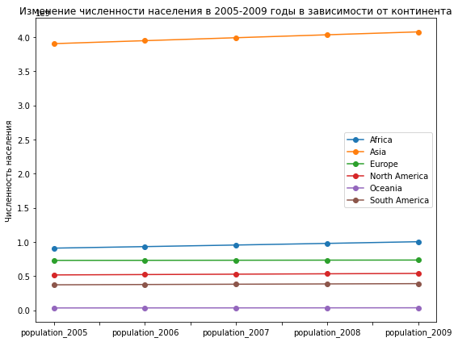

```python
fig, axes = plt.subplots(
    figsize=(8, 6)
)


for i in population_by_continent.columns:
    population_by_continent.loc[:, i].plot(
        kind='line',
#         kind='box',
#         logy='sym',
        style='-o',
#         rot=0,
#         label='jja',
#         axes=axes[0]
    )
plt.ylabel('Численность населения')
plt.title('Изменение численности населения в 2005-2009 годы в зависимости от континента')
plt.legend(loc=7)
plt.tight_layout()
plt.plot()
plt.show()
```

Для каждого континента численность населения медленно, но верно поднималась. Но хочется детальнее. К тому же есть сложность со сравнениями в асолютных величинах. Добавим колонки с относительными изменениями каждой величины.

Для этого создадим функцию, которая будет брать нужные нам колонки и считать относительное изменение.

Например: колонка с именем `population_2005_2006` будет характеризовать, на какую долю изменилась численность населения в 2006 году относительно 2005.

```python
def relative_change(year1, year2, name):

    list_of_name = [
        str(name) + '_' + str(year1),
        str(name) + '_' + str(year2),
        str(name) + '_' + str(year1) + '_' + str(year2)
    ]

    df[list_of_name[2]] = (df[list_of_name[1]] - df[list_of_name[0]]) / df[list_of_name[0]]
```

```python
for name in [
    'population',
    'electric_power',
    'energy_imports',
    'birth_rate',
    'internet_users',
    'co2',
    'tax_revenue',
    'gdp',
    'agriculture',
    'gross_savings'
]:
    for year in range(2005, 2009):
        relative_change(year, year+1, name)
```

Теперь у нас есть относительные изменения всех величин.

Посмотрим на распределение относительного изменения численности населения по годам.

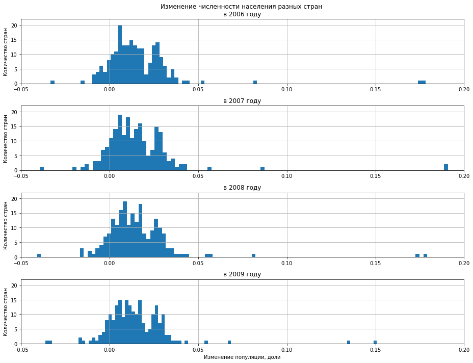

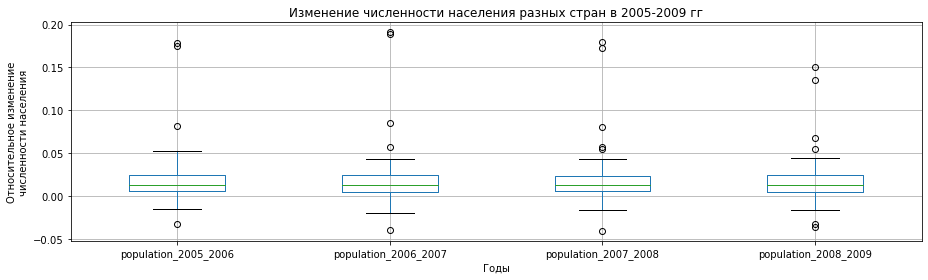

```python
BINS = 100
POPULATION_CHANGE_LIST = ['population_2005_2006', 'population_2006_2007', 'population_2007_2008', 'population_2008_2009']
POPULATION_LIST = ['population_2005', 'population_2006', 'population_2007', 'population_2008', 'population_2009']
fig, axes = plt.subplots(4,
                         1,
                         figsize=(13, 10)
                        )

df.population_2005_2006.hist(bins=BINS, ax=axes[0])
df.population_2006_2007.hist(bins=BINS, ax=axes[1])
df.population_2007_2008.hist(bins=BINS, ax=axes[2])
df.population_2008_2009.hist(bins=BINS, ax=axes[3])

for i in range(4):
    axes[i].set_ylabel('Количество стран')
    axes[i].set_xlim(-0.05, 0.2)
    axes[i].set_ylim(0, 22)
plt.xlabel('Изменение популяции, доли')
axes[0].set_title('Изменение численности населения разных стран \nв 2006 году')
axes[1].set_title('в 2007 году')
axes[2].set_title('в 2008 году')
axes[3].set_title('в 2009 году')
plt.tight_layout()
plt.show()

fig, axes = plt.subplots(figsize=(13,4))
df[POPULATION_CHANGE_LIST].boxplot(
#     kind='box',
#     logy=True,
    ax=axes
)
plt.title(f'Изменение численности населения разных стран в 2005-2009 гг')
plt.ylabel('Относительное изменение\nчисленности населения')
plt.xlabel('Годы')
plt.tight_layout()
plt.show()
```

- Распределение изменения численности населения в долях стремится к симметричному куполу, длинный правый хвост. Большинство стран имеют положительную динамику роста населения - до 0.05 долей от населения страны.
- Кризис 2008 снизил темпы увеличения численности населения для стран с наиболее высоким темпом, и не затронул ощутимо большинство стран - купол распределения не сместился влево - сторону негативной тенденции.

```python
print('Страны-лидеры по относительному приросту населения')
display(df.sort_values(by='population_2007_2008', ascending=False)[['country', 'population_2007_2008']].head(3))
display(df.sort_values(by='population_2008_2009', ascending=False)[['country', 'population_2008_2009']].head(3))
print('Страны-лидеры по относительному убыванию населения')
display(df.sort_values(by='population_2007_2008', ascending=False)[['country', 'population_2007_2008']].tail(3))
df.sort_values(by='population_2008_2009', ascending=False)[['country', 'population_2008_2009']].tail(3)
```

```
Страны-лидеры по относительному приросту населения
```

|  | country | population_2007_2008 |
| --- | --- | --- |
| 154 | Qatar | 0.179317 |
| 200 | United Arab Emirates | 0.172715 |
| 14 | Bahrain | 0.081062 |

|  | country | population_2008_2009 |
| --- | --- | --- |
| 154 | Qatar | 0.150810 |
| 200 | United Arab Emirates | 0.135275 |
| 14 | Bahrain | 0.067651 |

```
Страны-лидеры по относительному убыванию населения
```

|  | country | population_2007_2008 |
| --- | --- | --- |
| 4 | Andorra | -0.016275 |
| 155 | Romania | -0.016526 |
| 141 | Northern Mariana Islands | -0.040925 |

|  | country | population_2008_2009 |
| --- | --- | --- |
| 4 | Andorra | -0.016381 |
| 167 | Sint Maarten (Dutch part) | -0.032774 |
| 141 | Northern Mariana Islands | -0.036045 |

Выше всех относительный прирост численности населения в 2005-2009 году наблюдался в странах Персидского залива:

- 1 место - Катар
- 2 место - Объединенные Арабские Эмираты
- 3 место - Бахрейн

После кризиса 2008 года прирост стал меньше.

По относительному убыванию численности населения все годы лидируют Северные Марианские отсрова, после кризиса убывание числености стало меньше. Однако после кризиса нидерландская часть Синт-Мартена сильно просела в приросте населеия и появилась среди отрицательных выбросов значений.

```python
df[POPULATION_CHANGE_LIST].describe()
```

|  | population_2005_2006 | population_2006_2007 | population_2007_2008 | population_2008_2009 |
| --- | --- | --- | --- | --- |
| count | 213.000000 | 213.000000 | 213.000000 | 213.000000 |
| mean | 0.015728 | 0.015396 | 0.015286 | 0.014442 |
| std | 0.020478 | 0.021888 | 0.020807 | 0.018237 |
| min | -0.033198 | -0.039254 | -0.040925 | -0.036045 |
| 25% | 0.005275 | 0.005034 | 0.005468 | 0.004942 |
| 50% | 0.013039 | 0.012780 | 0.012948 | 0.012500 |
| 75% | 0.024580 | 0.024404 | 0.023150 | 0.023887 |
| max | 0.178337 | 0.191047 | 0.179317 | 0.150810 |

- Средние и медианные значения изменения численности населения в долях уменьшились к 2009 году.

#### Выборка стран для подробного исследования

Посмотрим динамику по некоторым отдельным странам.

Нам подробнее хотелось бы рассмотреть следующие страны:

1. `Соединенные Штаты` (**Северная Америка**) -страна с самой развитой экономикой, с нее же и начался кризис.
1. `Российская Федерация`, `Украина` и `Республика Молдова` (**Европа**) - крупные страны после развала СССР с одним прошлым, но разными путями развития.
1. `Великобритания` (**Европа**) — одно из крупнейших государств Европы, постоянный член Совета Безопасности ООН. Бывший центр мировой империи, Великобритания и сейчас играет важную роль в международных делах. Экономика Великобритании — девятая в мире по уровню развития; военный бюджет страны — один из самых высоких в мире. [ссылка на источник](https://ru.wikipedia.org/wiki/Великобритания)
1. `Швейцария` (**Европа**) — одна из самых развитых стран мира, с самым высоким номинальным богатством взрослого населения и восьмым по величине ВВП на душу населения. Она занимает передовые места по ряду международных показателей, включая экономическую конкурентоспособность и развитие человеческого потенциала. [ссылка на источник](https://ru.wikipedia.org/wiki/Швейцария)
1. `Норвегия` (**Европа**) — крупнейший производитель нефти и газа в Северной Европе. Доля нефтегазового сектора в ВВП — 23 % в 2015 году.С 2001 до 2006 и начиная с 2009 года Норвегия возглавляет список стран по индексу человеческого развития [ссылка на источник](https://ru.wikipedia.org/wiki/Норвегия#Экономика).
1. `Саудовская Аравия` (**Азия**) с её колоссальными запасами нефти — основное государство Организации стран — экспортёров нефти (ОПЕК). В 2015 году занимала первое место в мире по экспорту нефти, в 2017 году — второе место по добыче нефти (после России). Экспорт нефти составляет 95 % экспорта и 75 % доходов страны. [ссылка на источник](https://ru.wikipedia.org/wiki/Саудовская_Аравия)
1. `Босния и Герцеговина` (**Европа**) В период существования Югославии Босния и Герцеговина являлась беднейшей республикой, ныне — одна из беднейших стран Европы с очень высоким уровнем безработицы. [ссылка на источник](https://ru.wikipedia.org/wiki/Босния_и_Герцеговина)
1. `Китай` и `Гонконг` (**Азия**) Китай неуклонно развивается, а Гонконг - специальный административный район Китайской Народной Республики, один из ведущих глобальных городов и финансовых центров мира, занимает первое место по ожидаемой продолжительности жизни [ссылка на источник](https://ru.wikipedia.org/wiki/Гонконг)
1. `Япония` (**Азия**) — развитая страна с очень высоким уровнем жизни (девятнадцатое место по индексу развития человеческого потенциала). В Японии одна из самых высоких ожидаемых продолжительностей жизни [ссылка на источник](https://ru.wikipedia.org/wiki/Япония)
1. `Камбоджа` (**Азия**) — преимущественно аграрная страна. Основой экономики королевства является сельское хозяйство, в котором занято до 80% населения. Народное хозяйство находится пока только в процессе восстановления после потрясений XX века. У Камбоджи сформировался образ бедной страны [ссылка на источник](https://wikiway.com/cambodia/)
2. `Бангладеш` (**Азия**) Самая густонаселённая страна мира (без учёта карликовых стран) — 1120 человек на 1 км². Аграрно-индустриальная страна с развивающейся экономикой [ссылка на источник](https://ru.wikipedia.org/wiki/Бангладеш)

Создадим список с выбранными странами.

```python
SELECTED_COUNTRY = [
    'United States',
    'Russian Federation',
    'Ukraine',
    'Moldova',
    'United Kingdom',
    'Switzerland',
    'Norway',
    'Saudi Arabia',
    'Bosnia and Herzegovina',
    'China',
    'Hong Kong SAR China',
    'Japan',
    'Cambodia',
    'Bangladesh'
    ]
```

```python
short =  df[df.country.isin(SELECTED_COUNTRY)].set_index('country')
```

Посмотрим, как кризис отразился на этих странах.

Напишем функцию для визуализации изменения абсолютной и относительной числености населения.

Для асболютного изменения выбрали для наглядности логарифмическую шкалу.

```python
LEGEND_YEAR = list(range(2005, 2010))
LEGEND_YEAR_YEAR = ['2005_2006', '2006_2007', '2007_2008', '2008_2009']
```

```python
def show_population(countries, legend_loc1=0, legend_loc2=0, figsize=(13, 4), subplots=[1, 2]):
    fig, axes = plt.subplots(subplots[0], subplots[1], figsize=figsize)
    short.loc[short.index.isin(countries)][POPULATION_LIST].plot(kind='bar',
                                                           ax=axes[0],
                                                           logy=True,
                                                           rot=0)
    axes[0].legend(LEGEND_YEAR, loc=legend_loc1)

    axes[0].set_ylabel('Численность населения')
    short.loc[short.index.isin(countries)][POPULATION_CHANGE_LIST].plot(kind='bar',
                                                                  ax=axes[1],
                                                                  rot=0)
    axes[1].legend(LEGEND_YEAR_YEAR, loc=legend_loc2)
    axes[1].set_ylabel('Относительное изменение \nчисленности населения, доли')
    plt.suptitle(f'Изменение численности населения')
    plt.tight_layout()
    plt.show()
```

```python
def show_population_1(countries, legend_loc1=0, legend_loc2=0, figsize=(13, 4)):
    subplots=[1, len(countries)]

    fig, axes = plt.subplots(subplots[0], subplots[1], figsize=figsize)
    count = 0
    for i in countries:

        short.loc[short.index.isin([i])][POPULATION_LIST].plot(kind='bar',
                                                               ax=axes[count] if len(countries) > 1 else axes ,
                                                               logy=True,
                                                               rot=0)
        axes[count].legend(LEGEND_YEAR, loc=legend_loc1)
        count += 1

    axes[0].set_ylabel('Численность населения')
#     axes[0].legend(loc=legend_loc1)

    plt.suptitle(f'Изменение численности населения')

    plt.tight_layout()
    plt.show()
```

```python
def show_population_2(countries, legend_loc1=0, legend_loc2=0, figsize=(13, 4)):
    fig, axes = plt.subplots(1, 1, figsize=figsize)
    short.loc[short.index.isin(countries)][POPULATION_CHANGE_LIST].plot(kind='bar',
                                                                        ax=axes,
                                                                        rot=0)
    axes.legend(LEGEND_YEAR_YEAR, loc=legend_loc2)
    axes.set_ylabel('Изменение относительной \nчисленности населения, доли')
    plt.suptitle(f'Относительное изменение численности населения')
    plt.tight_layout()
    plt.show()
```

#### Соединенные Штаты - страна-зачинщик кризиса

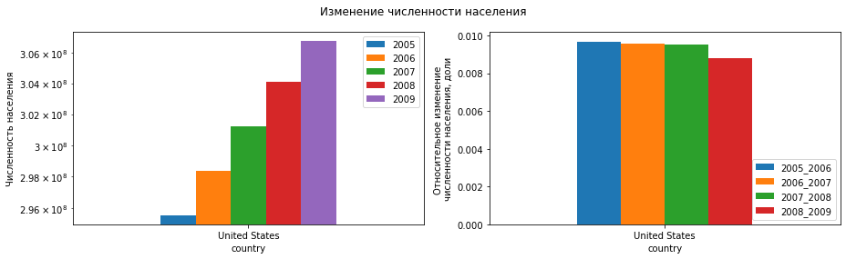

```python
show_population(['United States'], legend_loc2=4)
```

- В стране, с которой начался кризис, после него темп прироста населения просел.

#### Развитые страны Европы: Великобритания

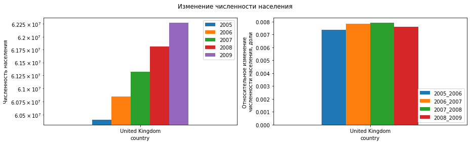

```python
show_population(['United Kingdom'], legend_loc2=4)
```

- В Великобритании кризис так же незначительно снизил темпы прироста населения.

#### Развитые страны Европы: Норвегия и Швейцария

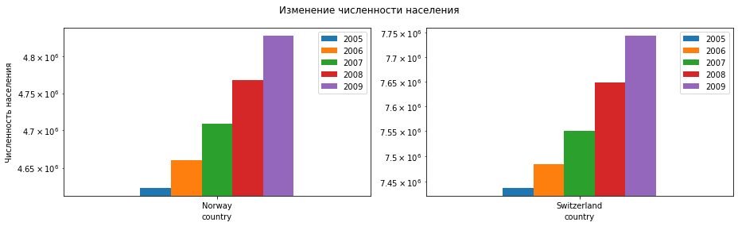

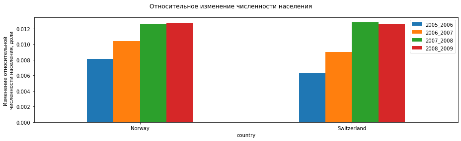

```python
show_population_1(['Norway', 'Switzerland'])
show_population_2(['Norway', 'Switzerland'])
```

- Развитые европейские страны в 2005-2009 году увеличивали численность своего населения.
- Кризис замедлил скорость прироста в Швейцарии сильнее, чем в Норвегии.

#### Бедные страны Европы: Босния и Герцеговина

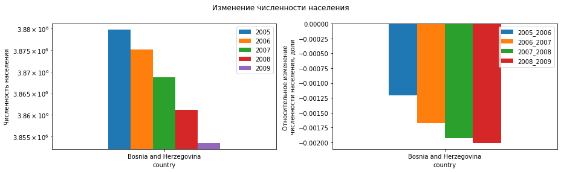

```python
show_population(['Bosnia and Herzegovina'], legend_loc2=1)
```

#### Страны СНГ: Украина, Российская Федерация, Республика Молдова

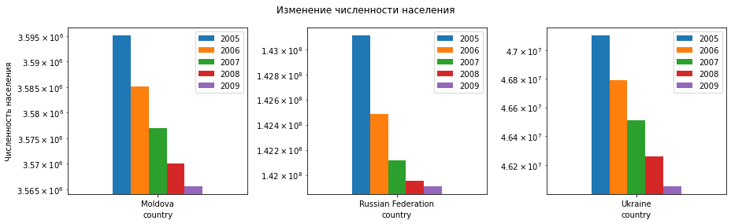

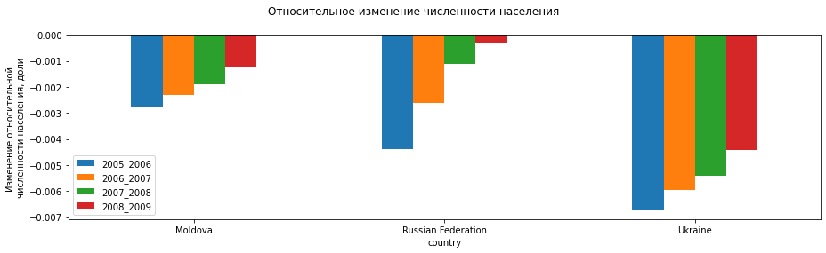

```python
CIS = [
    'Moldova',
    'Russian Federation',
    'Ukraine'
 ]
show_population_1(CIS)
show_population_2(CIS)
```

- Страны бывшего СССР в 2005-2009 году сокращали свою популяцию. Относительное сокращение, однако, для всех этих стран замедляло свой темп.
- К 2009 году Российская федерация даже начала приближаться к отсутсвию изменений в численности населения.
- Наибольшее относительное сокращение населения в эти годы наблюдалось на Украине.

#### Развитые страны Азии: Китай и Гонконг, Япония

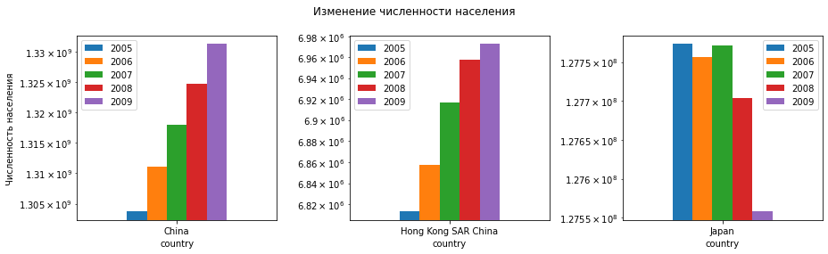

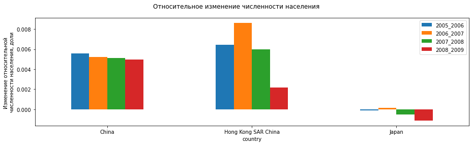

```python
RICH_ASIA = [
    'China',
    'Hong Kong SAR China',
    'Japan'
    ]
show_population_1(RICH_ASIA)
show_population_2(RICH_ASIA)
```

- Китай и Гонконг увеличивали в данные годы численность своего населения.
- Темп роста в Китае снижался и кризис никак не отразился.
- Для Гонконга видно явное снижение темпа роста численности.
- У Японии в 2005-2009 году численность в основном убывала. Кризис ускорил этот процесс.

#### Бедные страны Азии: Камбоджа и Бангладеш

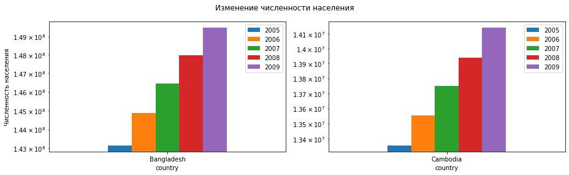

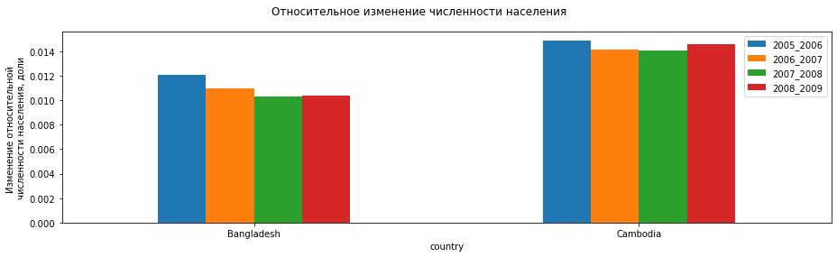

```python
POOR_ASIA = [
    'Bangladesh',
    'Cambodia',
    ]
show_population_1(POOR_ASIA)
show_population_2(POOR_ASIA)
```

- Бедные страны Азии приращивали население в исследуемые годы, явного влияния кризиса не наблюдается.

#### Развитые страны Азии : Персидский залив, Саудовская Аравия

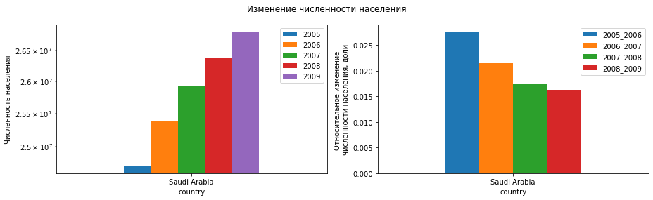

```python
show_population(['Saudi Arabia'], legend_loc2=1)
```

- Для нефтяного гиганта кризис оказал влияние на темпы снижения роста численности населения, темп уменьшения роста замедлился.

### **Отчет по влиянию кризиса 2008 г на потребление электроэнергии**

Подготовим списки исследуемых параметров.

```python
ELECTRIC_CHANGE_LIST = ['electric_power_2005_2006', 'electric_power_2006_2007', 'electric_power_2007_2008', 'electric_power_2008_2009']
ELECTRIC_LIST = ['electric_power_2005', 'electric_power_2006', 'electric_power_2007', 'electric_power_2008', 'electric_power_2009']
```

Оценим, как менялось потребление электроэнергии в разных странах с 2005 по 2009 гг.

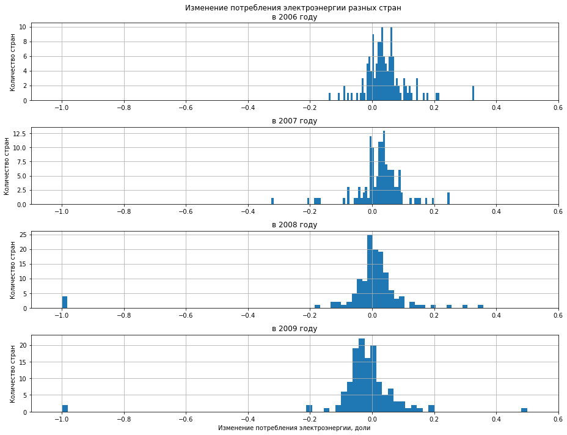

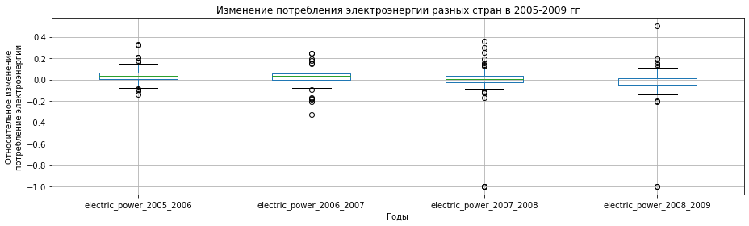

```python
BINS = 80
fig, axes = plt.subplots(4,
                         1,
                         figsize=(13, 10)
                        )

df.electric_power_2005_2006.hist(bins=BINS, ax=axes[0])
df.electric_power_2006_2007.hist(bins=BINS, ax=axes[1])
df.electric_power_2007_2008.hist(bins=BINS, ax=axes[2])
df.electric_power_2008_2009.hist(bins=BINS, ax=axes[3])

for i in range(4):
    axes[i].set_ylabel('Количество стран')
    axes[i].set_xlim(-1.1, 0.6)
#     axes[i].set_ylim(0, 25)
plt.xlabel('Изменение потребления электроэнергии, доли')
axes[0].set_title('Изменение потребления электроэнергии разных стран \nв 2006 году')
axes[1].set_title('в 2007 году')
axes[2].set_title('в 2008 году')
axes[3].set_title('в 2009 году')
plt.tight_layout()
plt.show()

fig, axes = plt.subplots(figsize=(13,4))
df[ELECTRIC_CHANGE_LIST].boxplot(
#     kind='box',
    ax=axes
)
plt.title(f'Изменение потребления электроэнергии разных стран в 2005-2009 гг')
plt.ylabel('Относительное изменение\nпотребление электроэнергии')
plt.xlabel('Годы')
plt.tight_layout()
plt.show()
```

```python
df[df.electric_power_2007_2008 == df.electric_power_2007_2008.min()][['country', 'electric_power_2007_2008']]
```

|  | country | electric_power_2007_2008 |
| --- | --- | --- |
| 67 | Gabon | -0.998975 |

```python
df[df.electric_power_2008_2009 == df.electric_power_2008_2009.min()][['country', 'electric_power_2008_2009']]
```

|  | country | electric_power_2008_2009 |
| --- | --- | --- |
| 40 | Colombia | -0.998925 |

- В период кризиса потребление электроэнергии большинства стран упало, мы наблюдаем это по смещению купола распределения за 2009 год в сторону отрицательных значений.
- Габон сильно снизил свой уровень электропотребления в 2008 г., и Колумбия в 2009 г.

Рассмотрим, как сказался кризис на потребление электроэнергии выбранных стран.

Напишем функции для визуализации графиков.

```python
def show_electric(countries, legend_loc1=0, legend_loc2=0, figsize=(13, 4), subplots=[1, 2]):
    fig, axes = plt.subplots(subplots[0], subplots[1], figsize=figsize)
    short.loc[short.index.isin(countries)][ELECTRIC_LIST].plot(kind='bar',
                                                           ax=axes[0],
                                                           logy=True,
                                                           rot=0)
    axes[0].legend(LEGEND_YEAR, loc=legend_loc1)

    axes[0].set_ylabel('Потребление электроэнергии \n(кВтч на душу населения)')
    short.loc[short.index.isin(countries)][ELECTRIC_CHANGE_LIST].plot(kind='bar',
                                                                  ax=axes[1],
                                                                  rot=0)
    axes[1].legend(LEGEND_YEAR_YEAR, loc=legend_loc2)
    axes[1].set_ylabel('Относительное изменение \nпотребления электроэнергии, доли')
    plt.suptitle(f'Изменение потребления электроэнергии')
    plt.tight_layout()
    plt.show()
```

```python
def show_electric_1(countries, legend_loc1=0, legend_loc2=0, figsize=(13, 4)):
    subplots=[1, len(countries)]

    fig, axes = plt.subplots(subplots[0], subplots[1], figsize=figsize)
    count = 0
    for i in countries:

        short.loc[short.index.isin([i])][ELECTRIC_LIST].plot(kind='bar',
                                                               ax=axes[count] if len(countries) > 1 else axes ,
                                                               logy=True,
                                                               rot=0)
        axes[count].legend(LEGEND_YEAR, loc=legend_loc1)
        count += 1

    axes[0].set_ylabel('Потребление электроэнергии \n(кВтч на душу населения)')
#     axes[0].legend(LEGEND_YEAR, loc=legend_loc1)


    plt.suptitle(f'Изменение потребления электроэнергии')

    plt.tight_layout()
    plt.show()
```

```python
def show_electric_2(countries, legend_loc1=0, legend_loc2=0, figsize=(13, 4)):
    fig, axes = plt.subplots(1, 1, figsize=figsize)
    short.loc[short.index.isin(countries)][ELECTRIC_CHANGE_LIST].plot(kind='bar',
                                                                        ax=axes,
                                                                        rot=0)
    axes.legend(LEGEND_YEAR_YEAR, loc=legend_loc2)
    axes.set_ylabel('Изменение относительного \nпотребления электроэнергии, доли')
    plt.suptitle(f'Относительное изменение потребления электроэнергии')
    plt.tight_layout()
    plt.show()
```

Приступим к рассмотрению выбранных стран.